# Visualização de Relações Bivariadas

Prof. Lupercio F. Bessegato

16/10/2020

## Relações Bivariadas:

O objetivo principal é a visualização de conjunto multivariados. Nesta tarefa, os gráficos bivariados são extermamente importantes e costumam ser a primeira alternativa para a obtençao de padrão gráfico dos dados. A exibição da relação entre duas variáveis dependerá das medidas de cada variável, ou seja, se ela são nominais, ordinais, discretas ou contínuas. Há tipos de gráficos e cuidados adequados a cada uma dessas situações. Na visualização bivariada, podemos resslatar as técnicas baseadas em pontos, como o caso do *scatter plot matrix* e as técnicas de redução de dimensionalidade que buscam projetar em um espaço 2D os pontos de um espaço multidimensional. Essas técnicas são extensamente exploradas em multivariada e podemos citar: análise de componentes principais, análise fatorial, escalonamento multidimentsional. Essa última uma técnica bastante interessante em sua concepção de manter a ordenação dos pontos. Vamos aqui discutir as possibilidades e os problemas na construção de gráficos de dispersão e de *scatter plot matrix*. É sempre importante insepcionar a matriz de correlações dos dados nesse contexto de gráficos bivariados. Nesse sentido estaremos discutindo algumas possibilidades na visualização das matrizes de correlações que facilitarão bastante a exploração multivariada.

## Gráficos bivariados

Apresentamos a seguir comandos e detalhes de gráficos bivariados usando o bastante conhecido conjunto de dados `iris, que apresenta 4 variáveis contínuas relacionadas com medidas morfológicas das flores iris e uma categórica que tem como níveis três de suas espécies.

### Gráficos entre variável quantitativa e categórica:

#### Box- Plot:

Tipo bastante conhecido de gráfico, mas que eventualmente pode resumir demais os dados.

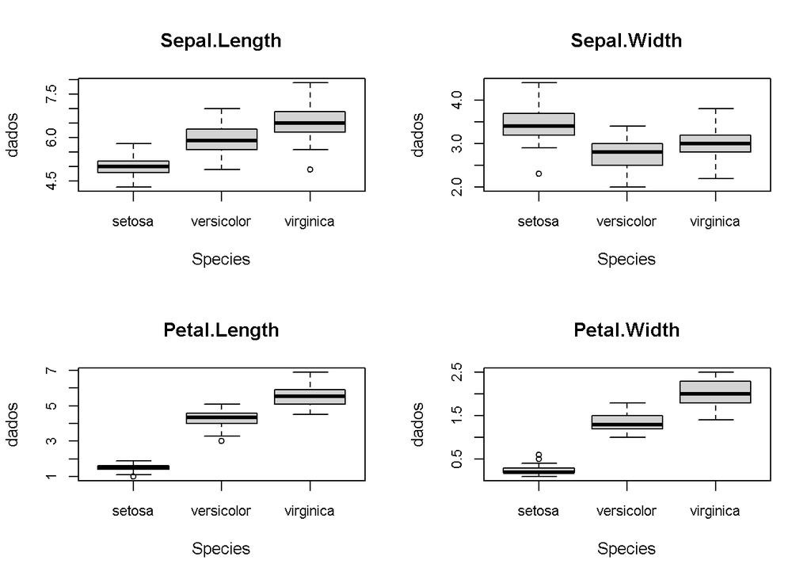

```r
            # Box-plots - quantitativa vs. categórica

variaveis <- names(iris[-5])
par(mfrow = c(2, 2))
for(i in 1: length(variaveis)) {
    with(iris, {
        dados <- eval(parse(text = variaveis[i]))
        boxplot(dados ~ Species, data = iris, main = variaveis[i],
              cex.axis = 0.85)
    })
}
```

```r
par(mfrow = c(1, 1))
```

#### *Violin plot*:

O *violin plot* é um método para visualizar dados numéricos. É semelhante a um *box-plot*, agregando entretanto uma suavização por núcleo da densidade, rebatida girado em cada lado. Enquanto um *box-plot* mostra apenas as estatísticas resumo, como mediana e intervalos interquartílicos, o *violin plot* apresenta as distribuição completa dos dados. assim, o *box-plot* é conveniente para comparar estatísticas, mas não permite ver variações nos dados. Para distribuições multimodais (aquelas com vários picos), isso pode ser particularmente limitante. Por outro lado, o *violin plot* é um híbrido ddo *box plot* com a suavização por *núcleo-estimador*, podendo mostrar os picos dos dados

```r
library(vioplot)
```

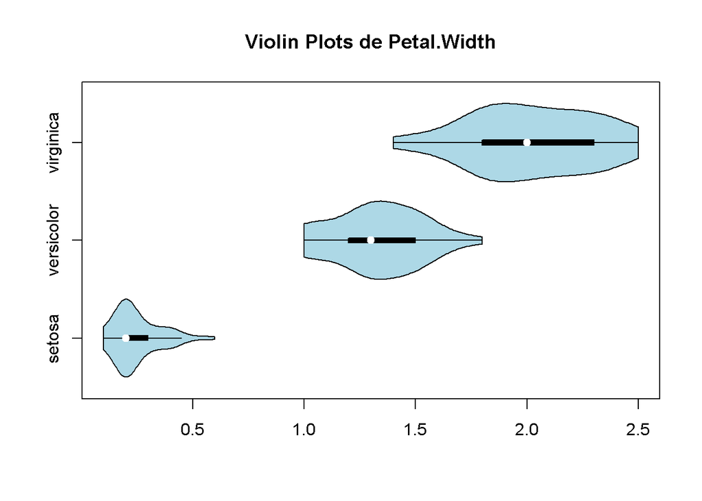

```r
nomes <- levels(iris$Species)
with(iris,{
    #for(i in 1:3) assign(paste0("x",i), Petal.Width[Species == nomes[i]])
    for(i in 1:3) assign(paste("x",i, sep=""),
        Petal.Width[Species == nomes[i]])
    vioplot(x1, x2, x3, names = nomes, col = "lightblue", horizontal = TRUE)
                            # col = "gold"
    title("Violin Plots de Petal.Width")
}) # end with
```

### Diagramas de dispersão

O diagrama de dispersão (*scatter plot*) é a forma mais simples de visualização gráfica de duas variáveis quantitativas, com cada variável representada em um dos eixos. Por exemplo, com o conjunto de dados `iris`, plotamos `Petal.Length` vs. `Petal.Width` para as 150 flores do conjunto de dados.

#### *Scatter plot* simples:

Uso do formato fórmula (`Petal.Width ~ Petal.Length`) como argumento, já que dessa maneira pode-se declarar o conjunto de dados com o argumento `data = iris`

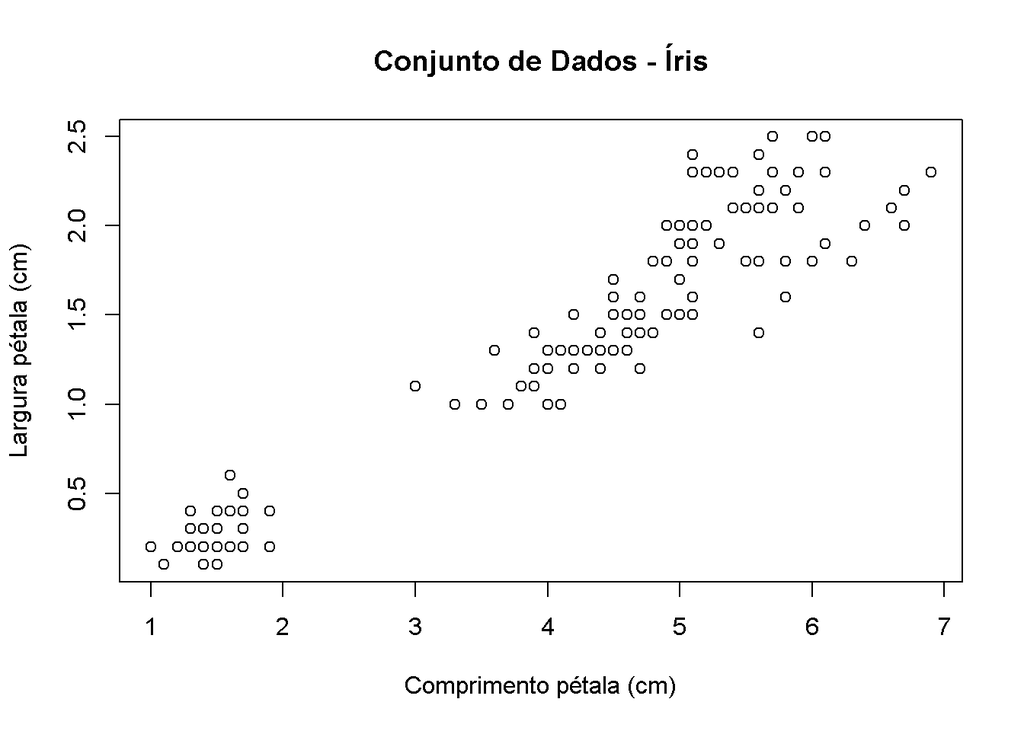

```r
plot(Petal.Width ~ Petal.Length, data = iris, main="Conjunto de Dados - Íris",
    xlab = "Comprimento pétala (cm)", ylab = "Largura pétala (cm)")
```

#### *Scatter plot* com visualização de fator:

*Scatter plot* das variáveis `Petal.Width`e `Petal.Length`, com o fator `Species` representado por carateres distintos (argumento `pch`)

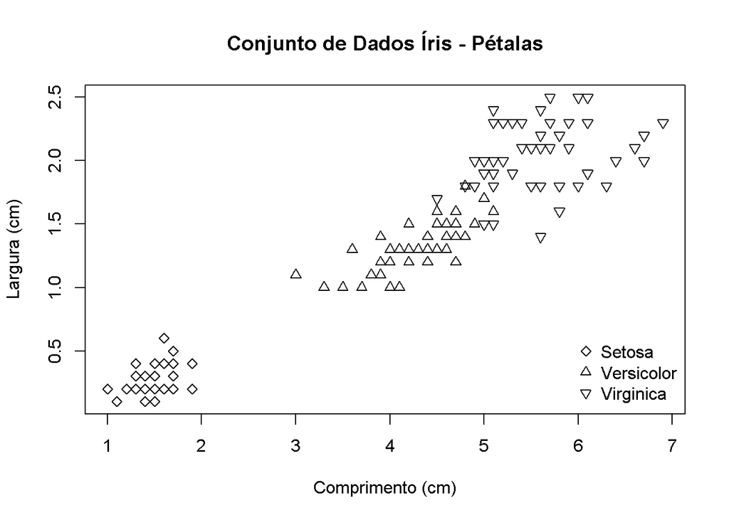

```r
    # Scatter plot com o fator 'Species' - Pétalas (por caracter)
plot(Petal.Width ~ Petal.Length, data = iris, xlab = "Comprimento (cm)",
     pch = c(23, 24, 25)[unclass(iris$Species)], ylab = "Largura (cm)",
     main = "Conjunto de Dados Íris - Pétalas")
  # legenda
legend("bottomright", legend = c("Setosa", "Versicolor", "Virginica"),
     pch = c(23, 24, 25), bty = "n")
```

*Scatter plot* das variáveis `Sepal.Width`e `Sepal.Length`, com o fator `Species` representado por cores distintas (argumento `bg`) e uso de caractere que pode ser preenchido (`pch = 21`)

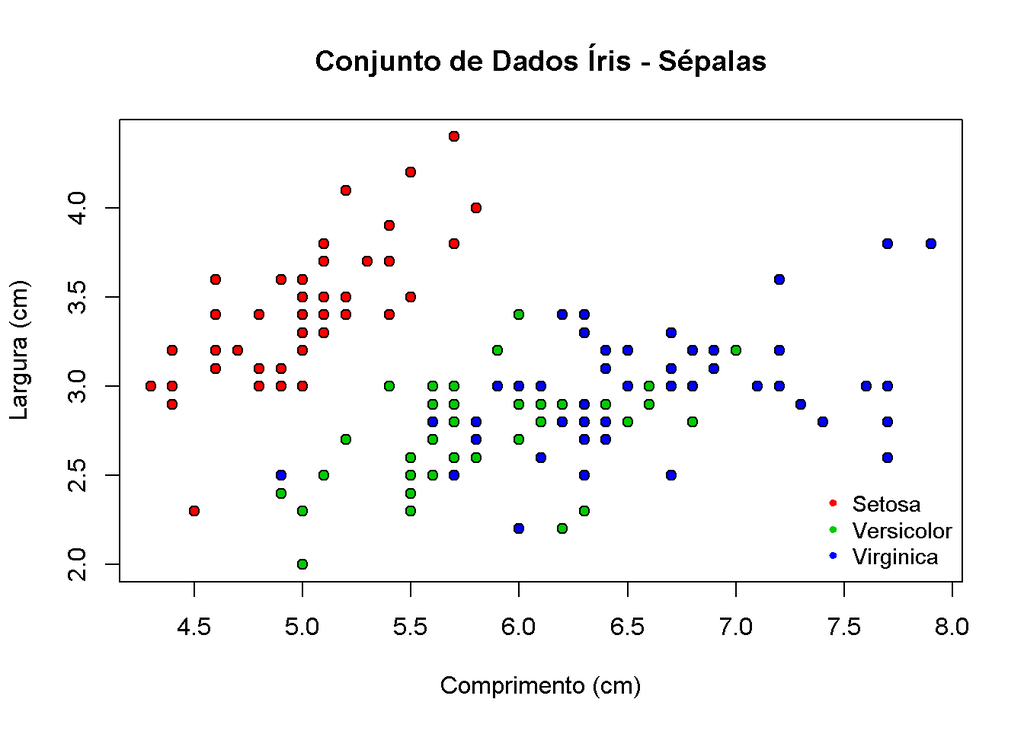

```r
    # Scatter plot com fator 'Species' - Sépalas (por cor)
plot(Sepal.Width ~ Sepal.Length, data = iris, xlab = "Comprimento (cm)",
     bg = c("red","green3","blue")[unclass(iris$Species)], pch = 21,
     ylab = "Largura (cm)", main = "Conjunto de Dados Íris - Sépalas")
  # legenda
legend("bottomright", legend = c("Setosa", "Versicolor", "Virginica"),
      pch = 20, col = c("red", "green3", "blue"), cex = 0.9, bty = "n")
```

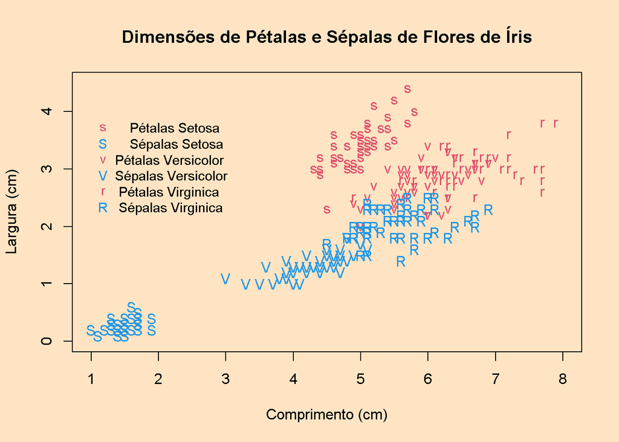

```r
    # Scatter plot com matplot - Todos comprimentos e larguras
iS <- iris$Species == "setosa"
iV <- iris$Species == "versicolor"
iG <- iris$Species == "virginica"
op <- par(bg = "bisque")
matplot(c(1, 8), c(0, 4.5), type =  "n",
      xlab = "Comprimento (cm)", ylab = "Largura (cm)",
        main = "Dimensões de Pétalas e Sépalas de Flores de Íris")
matpoints(iris[iS,c(1,3)], iris[iS,c(2,4)], pch = "sS", col = c(2,4))
matpoints(iris[iV,c(1,3)], iris[iV,c(2,4)], pch = "vV", col = c(2,4))
matpoints(iris[iG,c(1,3)], iris[iG,c(2,4)], pch = "rR", col = c(2,4))
legend(1, 4, c("    Pétalas Setosa", "    Sépalas Setosa",
               "Pétalas Versicolor", "Sépalas Versicolor",
           " Pétalas Virginica", " Sépalas Virginica"), cex=0.9,
       pch = "sSvVrR", col = rep(c(2,4), 3), bty = "n")
```

```r
par(op)
```

Uso do comando `matplot()` de array para criação do plot, com uma camada para cada espécie.

```r
        # Scatter plot com array e matplot

    # Criação da array
nome.var <- colnames(iris)[-5]
nome.esp <- as.character(unique(iris[,"Species"]))
    # criação array (uma matriz 50x3 para cada espécie)
iris.S <- array(NA, dim = c(50, 4, 3),
                dimnames = list(NULL, nome.var, nome.esp))
  # alocação dos valores no array, por camada
for(i in 1:3) iris.S[, , i] <- data.matrix(iris[1:50 + 50*(i-1), -5])
    # 1a. observação, 2a. camada
iris.S[1, , 2]
```

```
## Sepal.Length  Sepal.Width Petal.Length  Petal.Width
##          7.0          3.2          4.7          1.4
```

```r
    # 1a. observação, todas as camadas
iris.S[1, , ]
```

```
##              setosa versicolor virginica
## Sepal.Length    5.1        7.0       6.3
## Sepal.Width     3.5        3.2       3.3
## Petal.Length    1.4        4.7       6.0
## Petal.Width     0.2        1.4       2.5
```

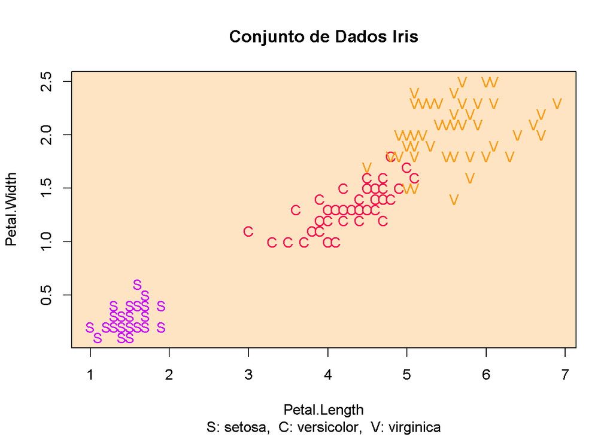

```r
    # scatter plot - bg apenas na região do gráfico
matplot(iris.S[, "Petal.Length", ], iris.S[, "Petal.Width", ], type = "n",
        sub = paste(c("S: ", "C: ", "V: "), dimnames(iris.S)[[3]],
                    sep = "", collapse= ",  "),
      xlab = "Petal.Length", ylab = "Petal.Width",
        main = "Conjunto de Dados Iris")
rect(par("usr")[1], par("usr")[3], par("usr")[2], par("usr")[4],
    col = "bisque")
matpoints(iris.S[, "Petal.Length", ], iris.S[, "Petal.Width", ], pch = "SCV",
        col = rainbow(3, start = 0.8, end = 0.1))
```

#### *Scatter plot* com o pacote `ggplot2`:

Necessária a instalação dos pacotes `ggplot2`e `gridExtra`

```r
        # Scatter plot com pacote ggplot2
library(ggplot2)
library(gridExtra)
```

Objeto gráfico (*graphical object - grob*) `sp1` contém os pares ordenados das variáveis relacionados com a fórmula `Petal.Width ~ Petal.Length`, com representação simples por pontos (`geo_point`).

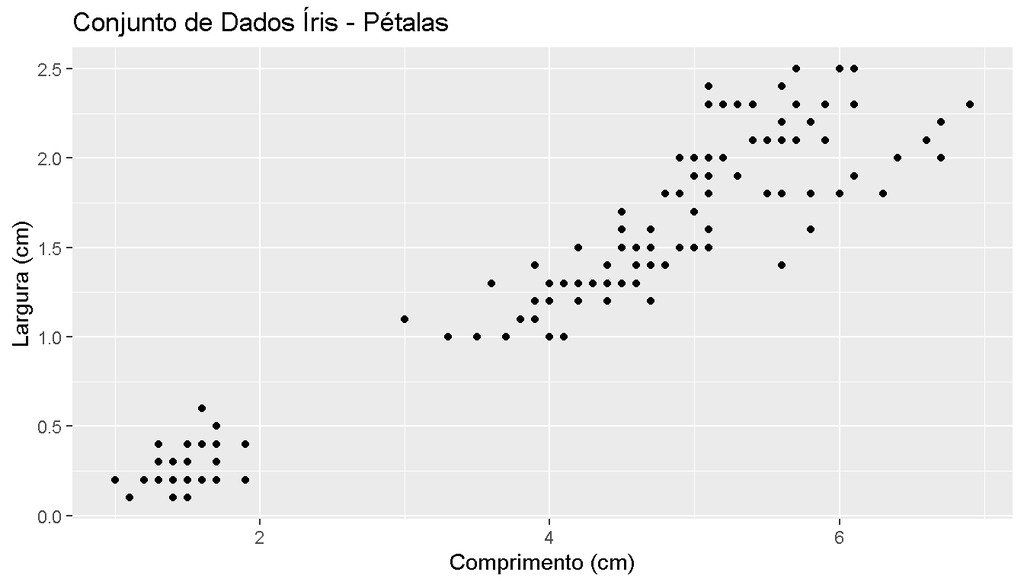

```r
    # Plot com pontos default
sp1 <- ggplot(iris, aes(x = Petal.Length, y = Petal.Width))
sp1 + geom_point() +
    xlab("Comprimento (cm)") + ylab("Largura (cm)") +
    ggtitle("Conjunto de Dados Íris - Pétalas")
```

O *grob* `sp2` é criado a partir do objeto `sp1`e contém os pontos coloridos por default, de acordo com os níveis do fator `SPecies`.

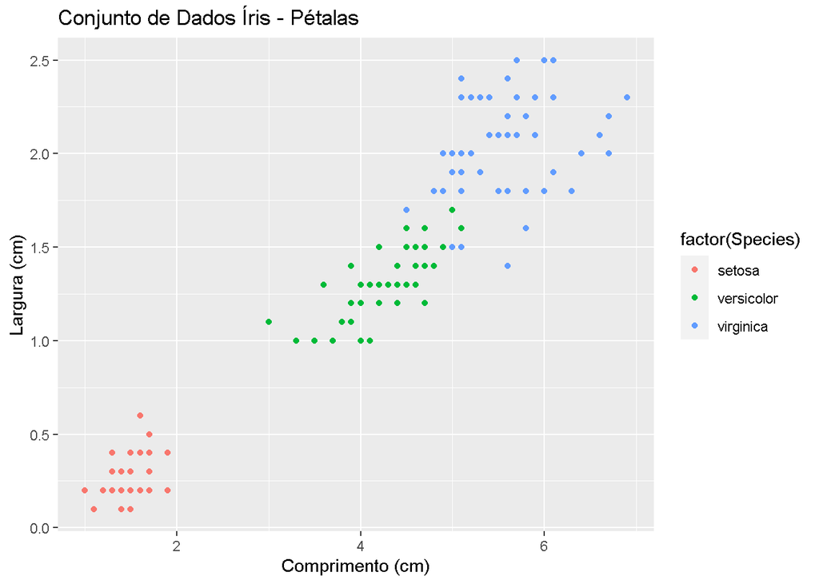

```r
  # cor p/ nível do fator Species
sp2 <- sp1 + geom_point(aes(color = factor(Species))) +
         xlab("Comprimento (cm)") + ylab("Largura (cm)") +
         ggtitle("Conjunto de Dados Íris - Pétalas")
sp2
```

O *grob* `sp3`é criado a partir do objetos `sp1`e contém os pontos coloridos conforme o usuário, de acordo com os níveis do fator `Species`.

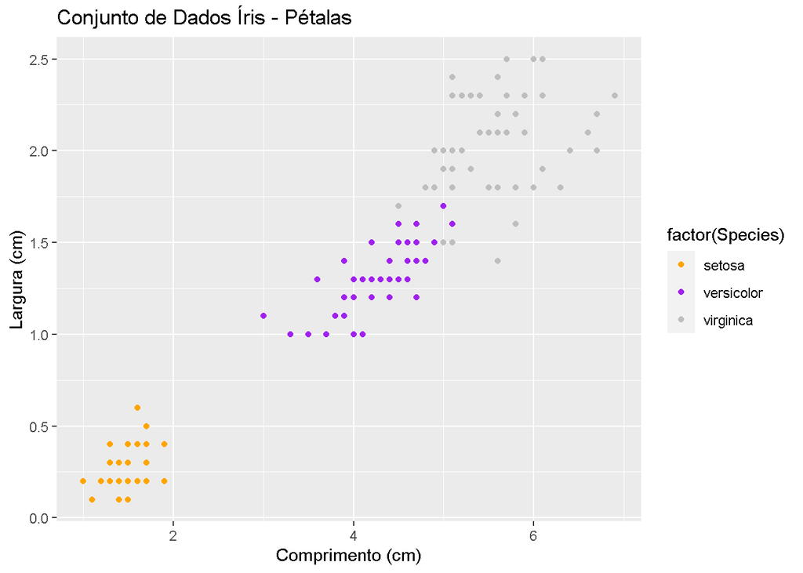

```r
    # Cores conforme usuário
sp3 <- sp1 + geom_point(aes(color=factor(Species))) +
        scale_color_manual(values = c("orange", "purple", "gray")) +
        xlab("Comprimento (cm)") + ylab("Largura (cm)") +
        ggtitle("Conjunto de Dados Íris - Pétalas")
sp3
```

O *grob* `sp4`é criado a partir do objetos `sp1`e contém os pontos com formato de caractere conforme o usuário, de acordo com os níveis do fator `Species`.

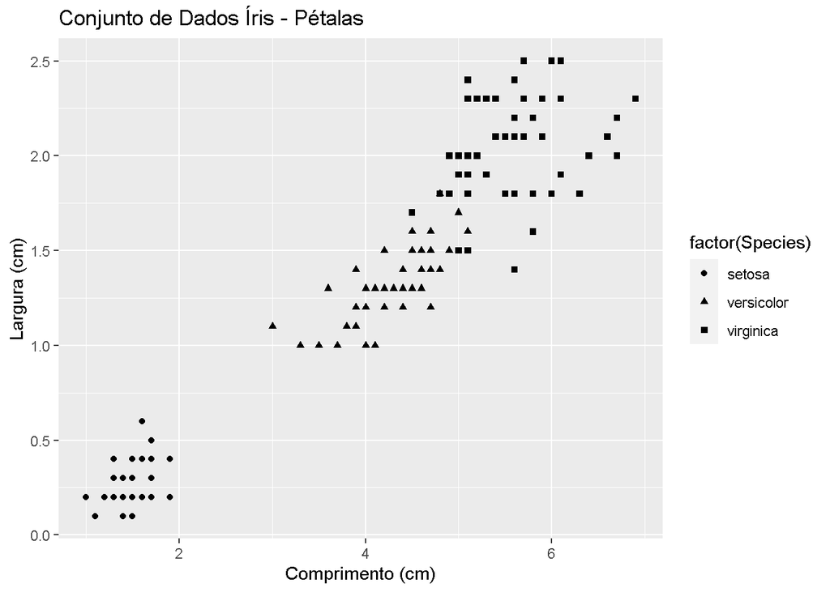

```r
  # forma e tamanho dos ponto conforme nível fator
sp4 <- sp1 + geom_point(aes(shape = factor(Species))) +
         xlab("Comprimento (cm)") + ylab("Largura (cm)") +
         ggtitle("Conjunto de Dados Íris - Pétalas")
sp4
```

Gráfico com cores default e formato dos pontos conforme usuário.

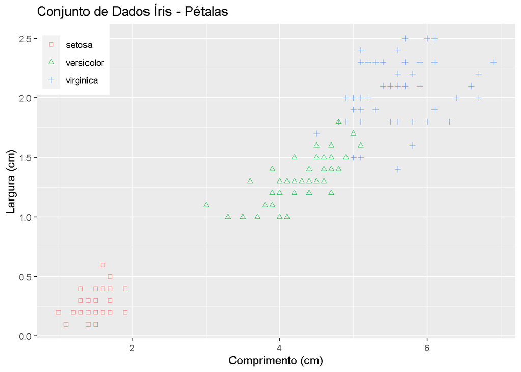

```r
    # Formato pontos cfe. usuário
sp1 + geom_point(aes(shape = factor(Species), color = factor(Species))) +
    scale_shape_manual(values = c(0, 2, 3)) +
    theme(legend.position = c(0,1), legend.justification = c(0,1)) +
    theme(legend.title = element_blank()) +
    xlab("Comprimento (cm)") +      ylab("Largura (cm)") +
    ggtitle("Conjunto de Dados Íris - Pétalas")
```

Uso da função `ggplot()` para criação do gráfico

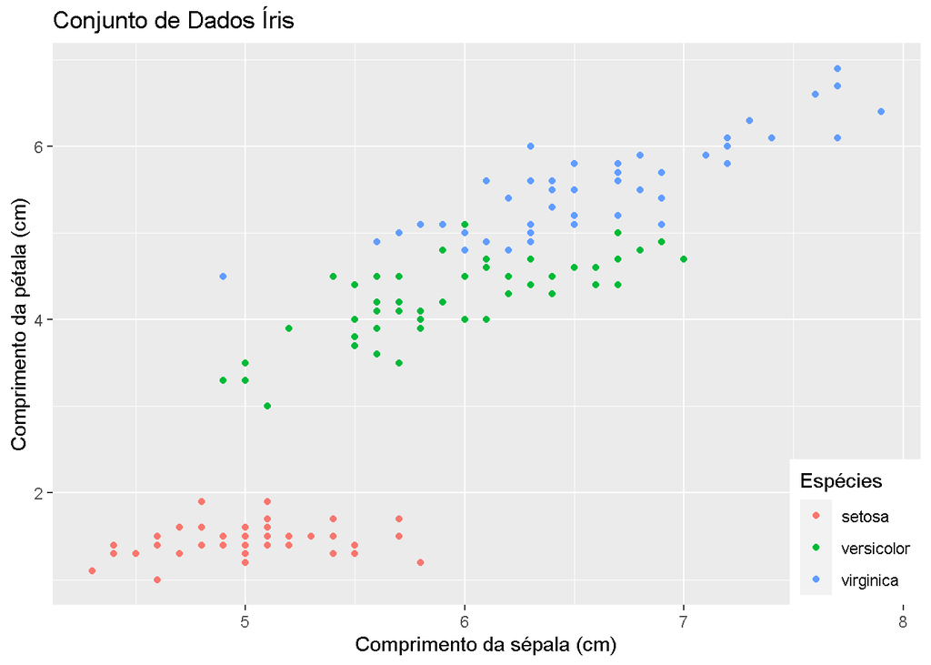

```r
    # Scatterplot comprimentos + espécies
ggplot(iris, aes(x = Sepal.Length, y = Petal.Length, color = Species)) +
    geom_point()+
    xlab("Comprimento da sépala (cm)") +    ylab("Comprimento da pétala (cm)") +
    ggtitle("Conjunto de Dados Íris") +
    scale_color_discrete(name ="Espécies") +
    theme(legend.position = c(1, 0), legend.justification = c(1, 0))
```

Criação de gráfico múltiplo dos *grobs* `sp2`, `sp3`e `sp4`, com a função `grid.arrange()`.

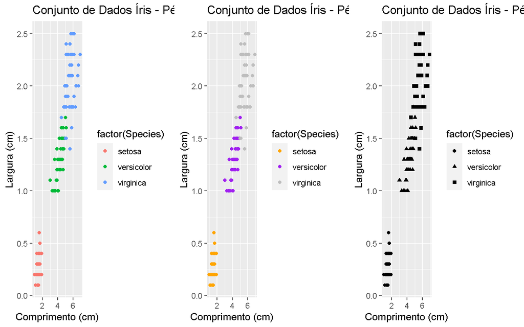

```r
    # painel com os gráficos
grid.arrange(sp2, sp3, sp4, nrow=1)
```

#### *Scatter plot* combinado com distribuição marginal:

Uso da função `rug()`para apresentar dispersão dos valores da variável nas margens do gráfico.

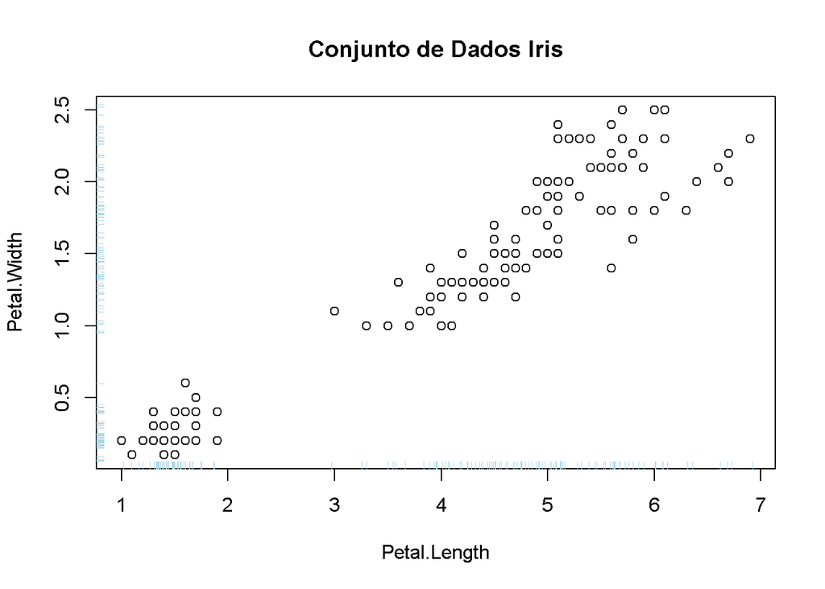

```r
    plot(Petal.Width ~ Petal.Length, data = iris, main = "Conjunto de Dados Iris",
        xlab = "Petal.Length", ylab = "Petal.Width")
with(iris, {
    rug(jitter(Petal.Length, amount = 0.05), side = 1, ticksize = 0.02,
        col = "light blue")
    rug(jitter(Petal.Width, amount = 0.05), side = 2, ticksize = 0.02,
        col = "light blue")
}) # end with
```

Construção de áreas para 3 gráficos por meio da função `layout()` e construção sequenciada dos três gráficos: gráfico de dispersão de `Petal.Length`e `Petal.Width`, histograma da variável `Petal.Length`e *box-plot* da variável `Petal,Width`.

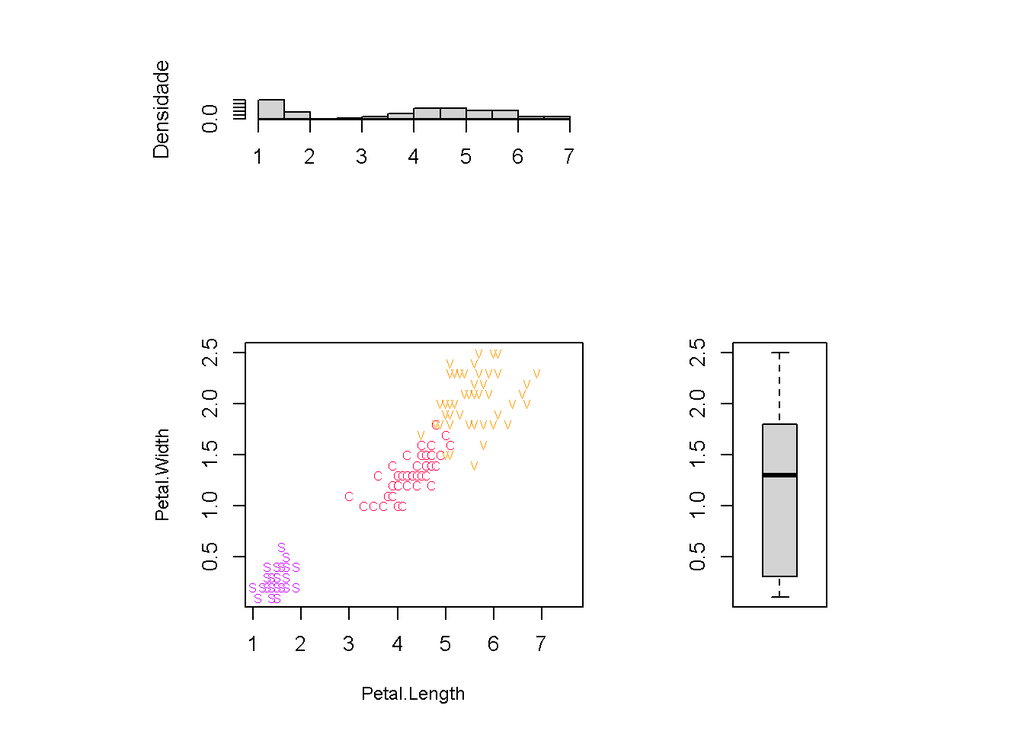

```r
  # Dispersão com marginais (histograma e boxplot)
layout(matrix(c(2,0,1,3), nrow = 2, byrow = T), respect = T,
       widths = c(2, 1), heights = c(1, 2))

xlim <- range(iris$Petal.Length) * 1.1

plot(Petal.Width ~ Petal.Length, data = iris, type = "n", xlim = xlim,
     cex.lab = 0.9, xlab = "Petal.Length", ylab = "Petal.Width")
points(Petal.Width ~ Petal.Length, data = iris, cex = 0.6,
       pch = c("S", "C", "V")[unclass(Species)],
       col = rainbow(3, start = 0.8, end = 0.1)[unclass(Species)])


hist(iris$Petal.Length, freq = F, ylab = "Densidade", main = NULL, xlab = NULL)
boxplot(iris$Petal.Width)
```

#### *Scatter plot* combinado com distribuição marginal - pacote `ggpubr` e `ggExtra`:

O pacote `ggExtra` permite o uso da função `ggMarginal()` que constrói vários tipos de gráficos univariados.

```r
        # Dispersão com marginais - pacote ggpubr
library(ggpubr)     # comando ggscatter
library(ggExtra)    # comando ggMarginal
```

O pacote `ggpubr`oferece a função `ggscatter()`, que constrói o objetos gráficos (*grobs*) de diagramas de dispersão, com inúmeros argumentos que permitem flexibidade na construção dos gráficos. O objetos `p` tem características relacionados com cores, tamnaho e trasparência das cores.

```r
p <- ggscatter(iris, x = "Petal.Length", y = "Petal.Width",
               color = "Species", palette = "jco",
               size = 3,       # size: tamanho dos pontos
               alpha = 0.6)      # alpha: transparência cores
```

*Marginal plot* construído com a função `ggMarginal()`, com gráficos de densidade em amabas as margens, obtidas com argumento `type = "density"`.

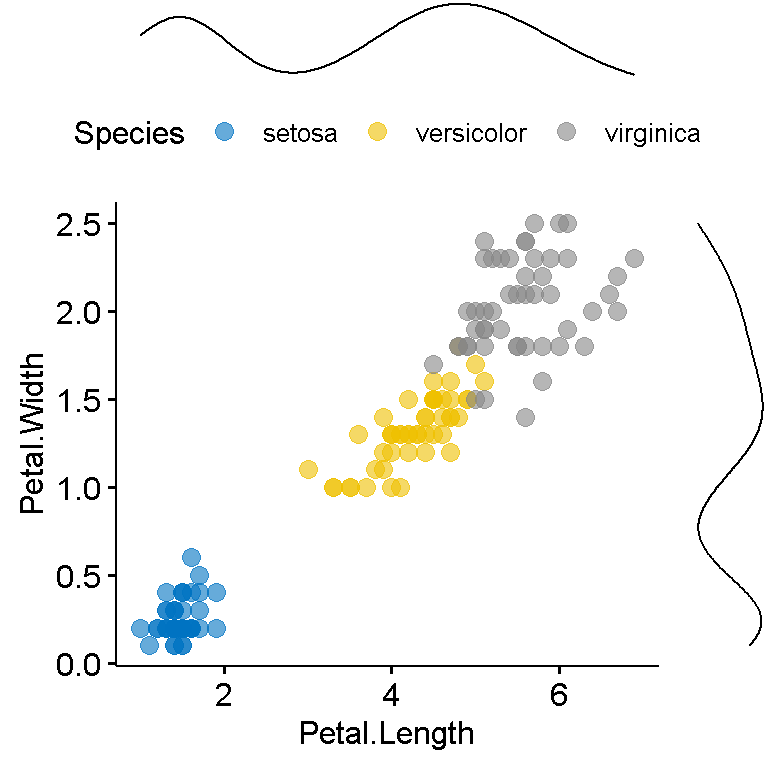

```r
ggMarginal(p, type = "density")
```

Margens do gráficos com *Box-plots*, obtidos com o argumento `type = "boxplot"`, da função `ggMarginal()`.

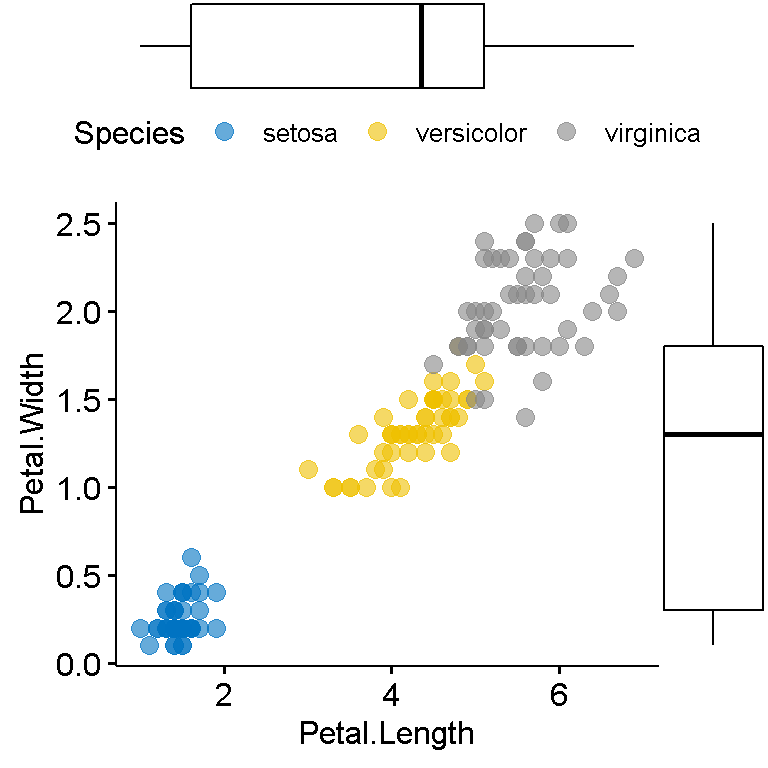

```r
    # marginais: box-plot
ggMarginal(p, type = "boxplot")
```

Margens do gráficos com histogramas, obtidos com o argumento `type = "histogram"`, da função `ggMarginal()`.

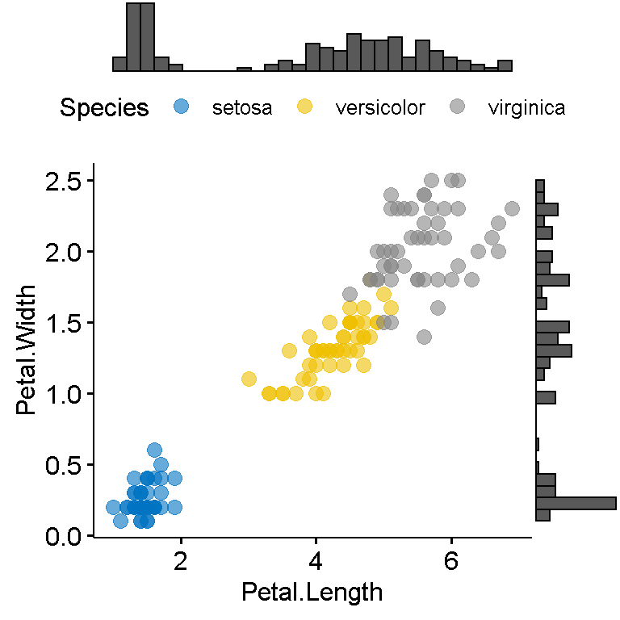

```r
    # marginais: histograma
ggMarginal(p, type = "histogram")
```

Gráficos de dispersão combinados com gráficos marginais, usando os pacotes `ggpubr` e `cowplot` com construção de gráfico por meio de *graphical objects* (*grobs* ). Nos casos abaixo usa-se o pacote `cowplot`porque o pacote `ggextra`não lida com vários grupos. Os gráficos apresentam um aparência melhor.

```r
library(ggpubr)
library(cowplot) # ggExtra não lida com vários grupos
```

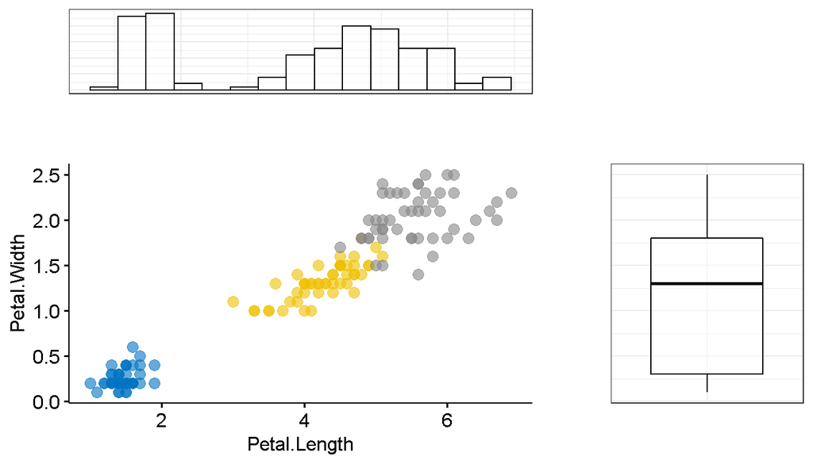

```r
    # marginais plots - x: histograma e y: box-plot

  # gráfico paralelo ao eixo x - histograma
xplot <- gghistogram(iris, x = "Petal.Length", bins = 15, ylab = "",
        ggtheme = theme_bw())
  # gráfico paralelo ao eixo y
yplot <- ggboxplot(iris, y = "Petal.Width", alpha = 0.5,
        xlab = "", ggtheme = theme_bw())
  # limpeza dos gráficos
p.b <- p + rremove("legend")
xplot <- xplot + clean_theme() + rremove("legend")
yplot <- yplot + clean_theme() + rremove("legend")
  # montagen gráfico com pacote cowplot
plot_grid(xplot, NULL, p.b, yplot, ncol = 2, align = "hv",
          rel_widths = c(2, 1), rel_heights = c(1, 2))
```

Gráfico de dispersão das variáveis `Petal.Length`e `Petal.Width`, combinados com gráficos suavizados de densidade por grupo coloridos. Gráficos de suavização de densidade facilitam a visualização dos dados e auxiliam muito na identificão de padrão dos dados.

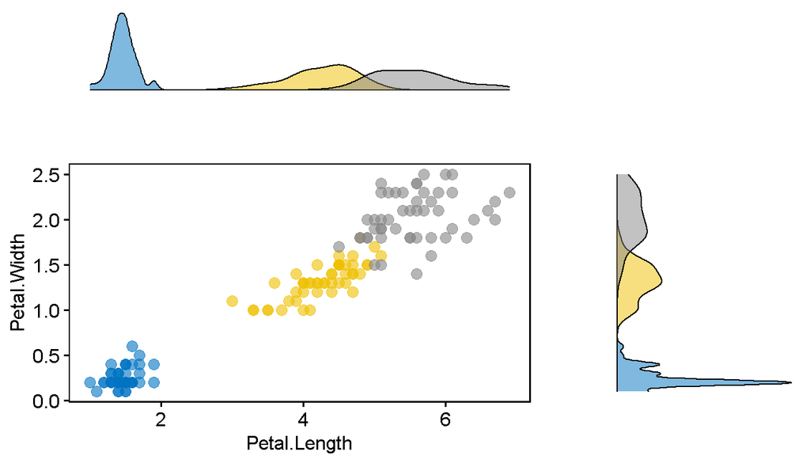

```r
      # Scatter plot e density marginal plots coloridos por grupos

  # scatter plot por grupo
sp1 <- ggscatter(iris, x = "Petal.Length", y = "Petal.Width", color = "Species",
            palette = "jco", size = 3, alpha = 0.6) + border()

  # densidades marginais por grupos
xplot1 <- ggdensity(iris, "Petal.Length", fill = "Species",
                   palette = "jco")
yplot1 <- ggdensity(iris, "Petal.Width", fill = "Species",
                   palette = "jco") + rotate()

  # limpeza dos gráficos
sp1 <- sp1 + rremove("legend")
yplot1 <- yplot1 + clean_theme() + rremove("legend")
xplot1 <- xplot1 + clean_theme() + rremove("legend")

  # montagem do gráfico com pacote cowplot
plot_grid(xplot1, NULL, sp1, yplot1, ncol = 2, align = "hv",
          rel_widths = c(2, 1), rel_heights = c(1, 2))
```

Gráfico de dispersão das variáveis `Petal.Length`e `Petal.Width`, combinados com box-plots coloridos por grupo.

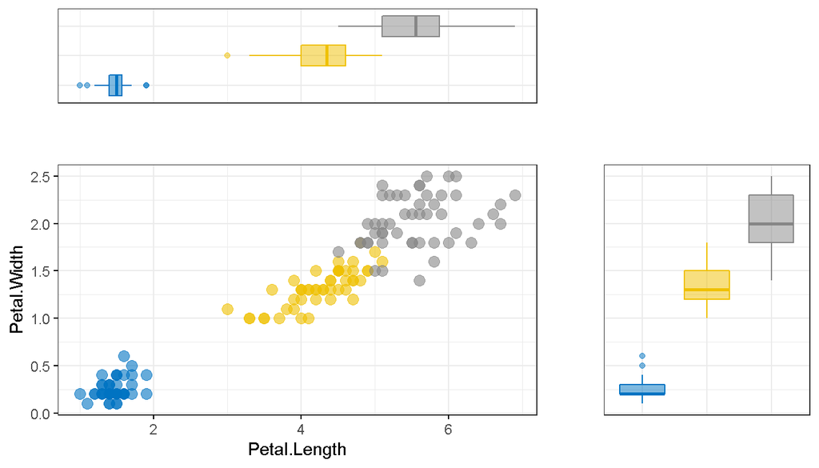

```r
      # Scatter plot e box-plots por grupos

  # scatter plot por grupo + ggtheme
sp2 <- ggscatter(iris, x = "Petal.Length", y = "Petal.Width", color= "Species",
            palette = "jco", size = 3, alpha = 0.6, ggtheme = theme_bw())
  # box-plots marginais
xplot2 <- ggboxplot(iris, x = "Species", y = "Petal.Length", color = "Species",
               fill = "Species", palette = "jco", alpha = 0.5,
               ggtheme = theme_bw()) + rotate()
yplot2 <- ggboxplot(iris, x = "Species", y = "Petal.Width", color = "Species",
               fill = "Species", palette = "jco", alpha = 0.5,
               ggtheme = theme_bw())
  # limpeza dos gráficos
sp2 <- sp2 + rremove("legend")
yplot2 <- yplot2 + clean_theme() + rremove("legend")
xplot2 <- xplot2 + clean_theme() + rremove("legend")

  # montagem do gráfico com pacote cowplot
plot_grid(xplot2, NULL, sp2, yplot2, ncol = 2, align = "hv",
          rel_widths = c(2, 1), rel_heights = c(1, 2))
```

#### *Scatter plot* com linha de regressão:

Dependendo da situação a reta de regressão ajuda a entender o padrão dos dados, no caso indicando a presença de clusters nos dados.

```r
    # Scatter plot com linha de regressão

  # reta de regressão y = Petal.Width, x = Petal.Length
petal.lm <- lm(Petal.Width ~ Petal.Length, data = iris)
summary(petal.lm)
```

```
##
## Call:
## lm(formula = Petal.Width ~ Petal.Length, data = iris)
##
## Residuals:
##      Min       1Q   Median       3Q      Max
## -0.56515 -0.12358 -0.01898  0.13288  0.64272
##
## Coefficients:
##               Estimate Std. Error t value Pr(>|t|)
## (Intercept)  -0.363076   0.039762  -9.131  4.7e-16 ***
## Petal.Length  0.415755   0.009582  43.387  < 2e-16 ***
## ---
## Signif. codes:  0 '***' 0.001 '**' 0.01 '*' 0.05 '.' 0.1 ' ' 1
##
## Residual standard error: 0.2065 on 148 degrees of freedom
## Multiple R-squared:  0.9271, Adjusted R-squared:  0.9266
## F-statistic:  1882 on 1 and 148 DF,  p-value: < 2.2e-16
```

```r
  # coeficiente de determinação da regressão
cor(iris$Petal.Length, iris$Petal.Width)^2
```

```
## [1] 0.9271098
```

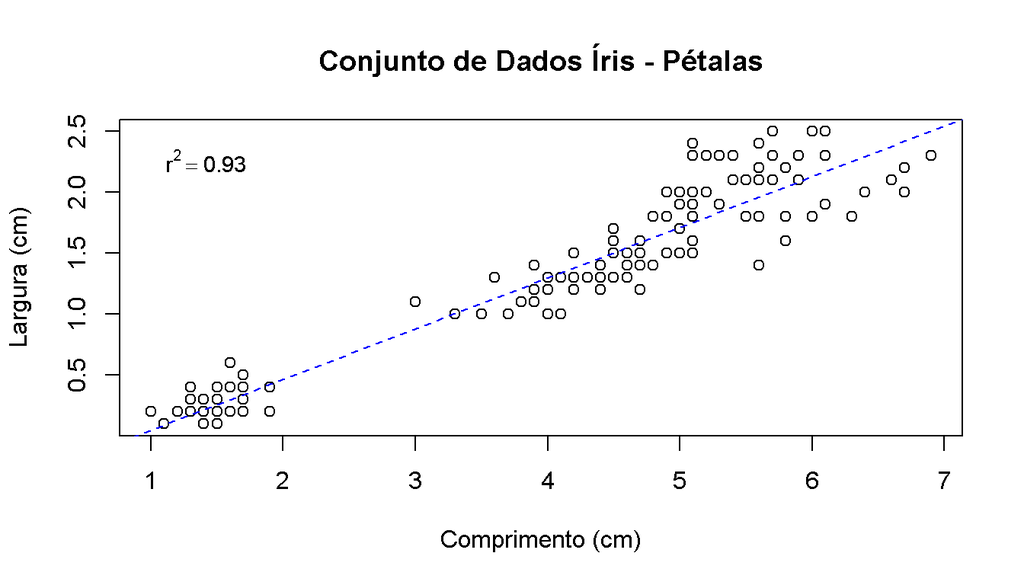

```r
  # scatter plot com reta de regressão
r2 <- summary(petal.lm)$r.squared

  # scatter plot e reta de regressão.
plot(Petal.Width ~ Petal.Length, data = iris,
    main = "Conjunto de Dados Íris - Pétalas", xlab = "Comprimento (cm)",
    ylab = "Largura (cm)")
  # reta de regressão
abline(petal.lm, lty = 2, col = "blue")
  # R2 informado no plot com uso de anotação matemática e variável
text(x = 1, y = 2.25, bquote(r^2 == .(round(r2,2), 3)), pos = 4, cex = 0.90)
```

O pacote `ggplot2`amplia as possibilidades de visualização da relação entre as duas variáveis.

```r
library(ggplot2)
```

O default do `ggplot2`é adicionar linha de regressão com banda de confiança de 95%.

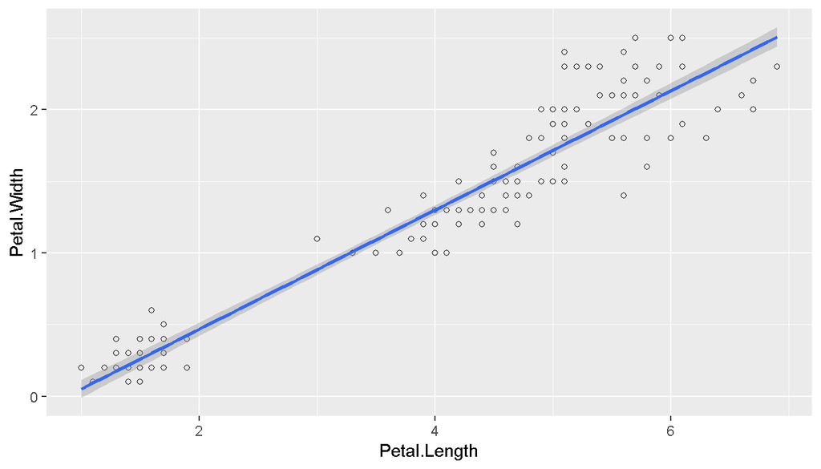

```r
# scatter plot e regressão c/ banda de confiança

ggplot(iris, aes(x = Petal.Length, y = Petal.Width)) +
  geom_point(shape = 1) +       # círculos vazios
  geom_smooth(method = lm)      # adiciona linha de regressão
```

```r
# default: banda de confianção de 95%
```

O argumento `se = FALSE` retira a banda de confiança do gráfico.

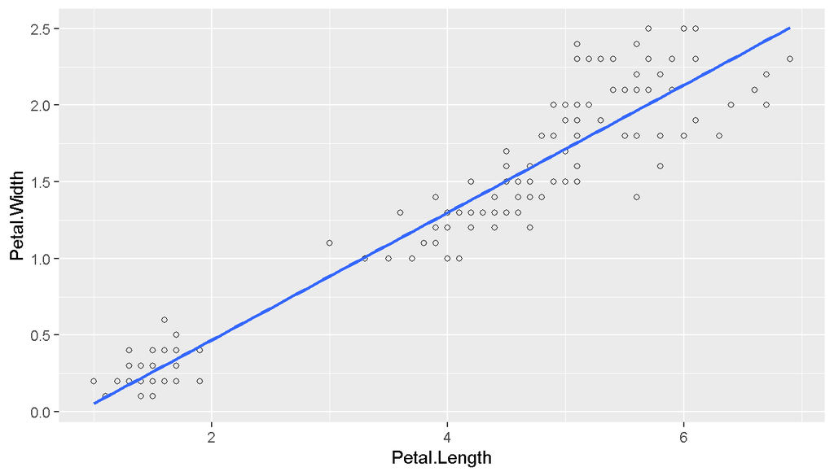

```r
# scatter plot e regressão s/ banda de confiança

ggplot(iris, aes(x = Petal.Length, y = Petal.Width)) +
  geom_point(shape = 1) +       # círculos vazios
  geom_smooth(method = lm,      # adiciona linha de regressão
              se = FALSE)       # sem banda de confiança
```

A função `geom_smooth()` adiciona linha de regressão suavizada. Seu argumento `method`tem como valores possíveis `"lm"` (a reta de regressão), `"glm"`, `"gam"`, `"loess"` ou uma função de regressão qualquer. A função `geom_smooth()`sem explicitação de arumento, desenhará uma linha *loess* com banda de confiança, entre os dados. *LOWESS* (*Locally Weighted Scatterplot Smoothing*), algumas vezes denominado LOESS (*locally weighted smoothing*), é uma ferramenta popular usada em análise de regressão que cria uma linha de regressão suavizada em um *scatter plot*. Ela ajuda a visualizar a relação entre as variáveis.

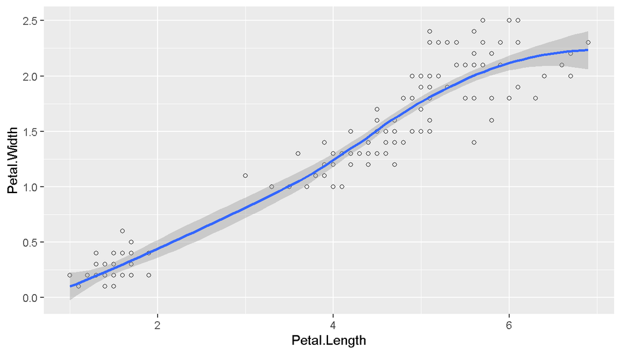

```r
# scatter plot e loess c/ banda de confiança

ggplot(iris, aes(x = Petal.Length, y = Petal.Width)) +
  geom_point(shape = 1) +       # círculos vazios
  geom_smooth()                 # adiciona curva suavizada loess
```

```r
# com banda de confiança
```

O argumento `se = FALSE` retira a banda de confiança do gráfico.

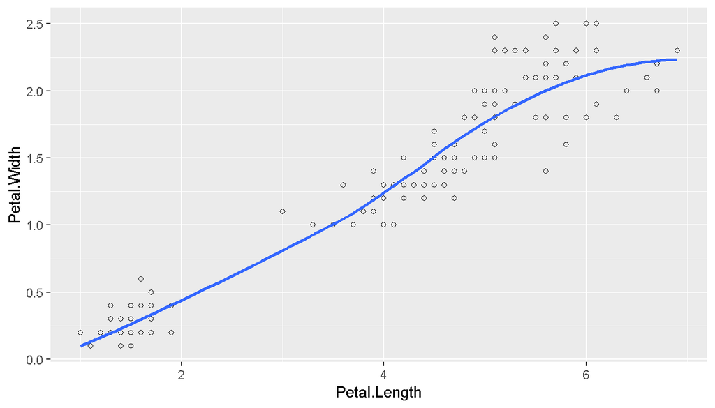

```r
# scatter plot e loess s/ banda de confiança

ggplot(iris, aes(x = Petal.Length, y = Petal.Width)) +
  geom_point(shape = 1) +       # círculos vazios
  geom_smooth(method = "loess", # adiciona curva suavizada loess
              se = FALSE)       # sem banda de confiança
```

No `ggplot2`os códigos dos formatos dos pontos são dados pela tabela abaixo:

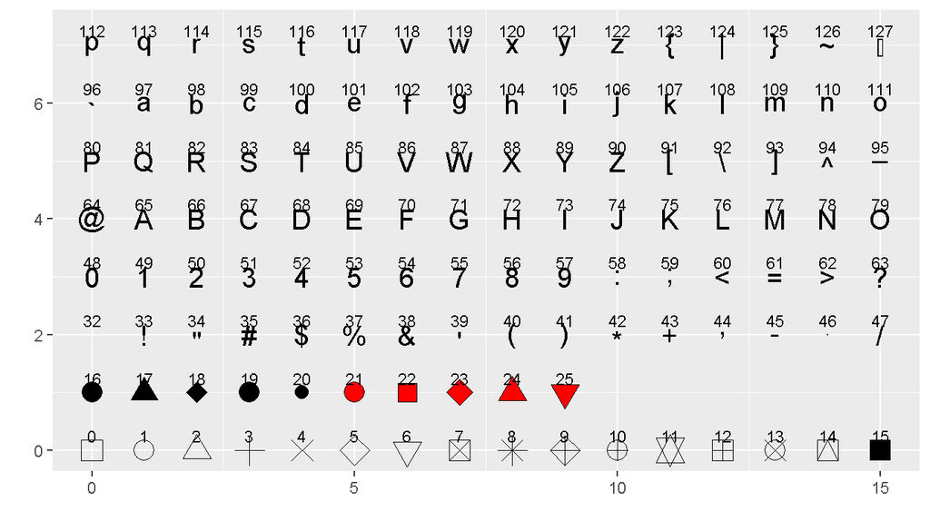

Assim, pode-se customizar o formato dos pontos por nível do fator `Species`, optando-se por: círculo vazio (1), triângulo (2) e cruz (3).

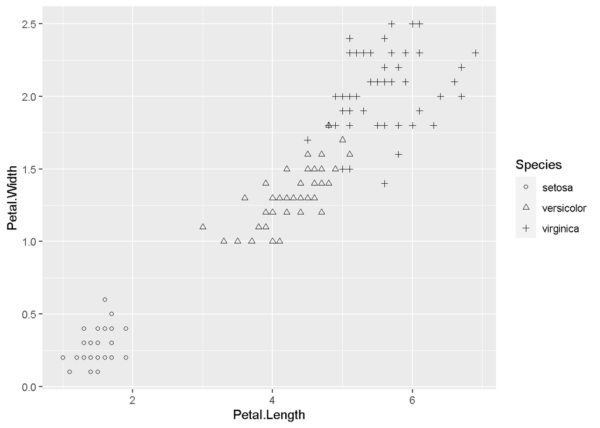

```r
  # ajusta pontos por Species, com formatos diferentes
ggplot(iris, aes(x = Petal.Length, y = Petal.Width, shape = Species)) +
          geom_point() +
          scale_shape_manual(values = c(1, 2, 3))  # círculo vazio, triângulo e
```

```r
                                                 # cruz
```

Aqui, o argumento `shape = 1`da função `geom_point()` plotará círculos vazios nos pontos dos dados, os quais são coloridos de acordo com o fator `Species`. A função `aes(group = 1)` imporá uma única reta de regressão pelos dados.

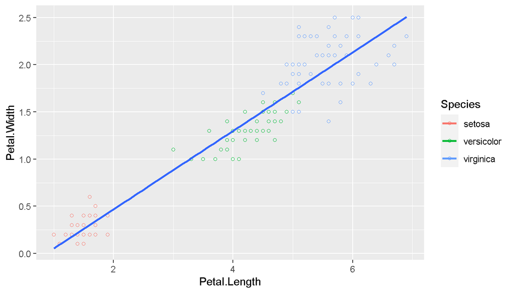

```r
  # scatter plot com cores por Species

ggplot(iris, aes(x = Petal.Length, y = Petal.Width, color = Species)) +
    geom_point(shape = 1) +       # círculos vazios
    geom_smooth(method = lm ,   # adiciona reta de regressão
            aes(group = 1),         # única reta
            se = FALSE)               # sem banda de confiança
```

O default é uma reta de regressão por nível da variável `Species`já que foi imposto no comando `aes()`geral. Foi usado um *pallete* um pouco mais escuro que o normal.

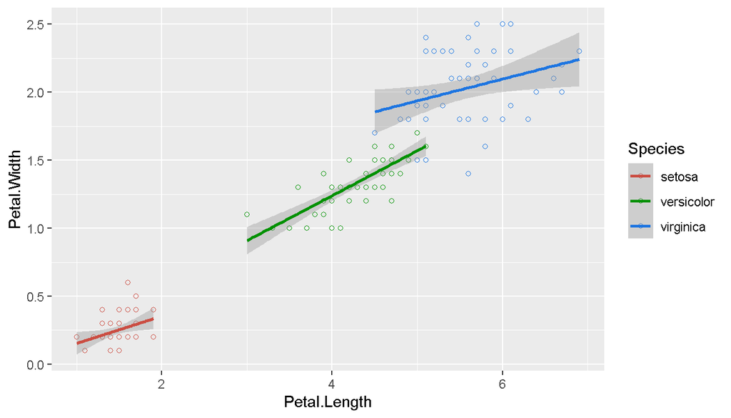

```r
    # scatter plot com cores e linhas de regressão distintos p/ grupo

ggplot(iris, aes(x = Petal.Length, y = Petal.Width, color = Species)) +
    geom_point(shape = 1) +         # círculos vazios
    scale_colour_hue(l = 50) +    # paleta um pouco mais escura que a normal
    geom_smooth(method = lm)      # adiciona retas de regressão
```